# Analysing word counts

Sebastian Sauer

3 8 2017

Let’s perform some initial analyses of polit tweets.

# Setup

First load some libraries.

```r
library(tidyverse)
library(readr)
library(lubridate)
library(magrittr)
library(tidytext)
library(stringr)
library(viridis)
library(wordcloud)
library(SnowballC)
library(knitr)
```

And the data.

```r
load("../data_polit_twitter/tweets_df.Rdata")
polits_df <- read_csv("../data_polit_twitter/polits_df.csv")
```

# Tweet period

period from first to most recent tweet

```r
tweets_df %>%
  group_by(screenName) %>%
  summarise(first_tweet = min(created),
            recent_tweet = max(created)) %>%
  mutate(tweet_period = interval(first_tweet, recent_tweet) / ddays(1)) -> polit_periods


tweets_df %>%
  left_join(polit_periods, by = "screenName") -> dummy
```

## How many accounts, how many tweets each?

## Who tweetet most?

```r
tweets_df %>%
  count(screenName, sort = TRUE) -> tweets_per_screenName


tweets_per_screenName %>%
  head(10)
```

```
## # A tibble: 10 x 2
##         screenName     n
##              <chr> <int>
##  1 MechthildRawert  3243
##  2      PLengsfeld  3239
##  3       rischwasu  3237
##  4  MGrosseBroemer  3235
##  5        DoroBaer  3232
##  6     Elke_Ferner  3232
##  7   KerstinGriese  3232
##  8 brigittezypries  3228
##  9       tj_tweets  3227
## 10        LischkaB  3225
```

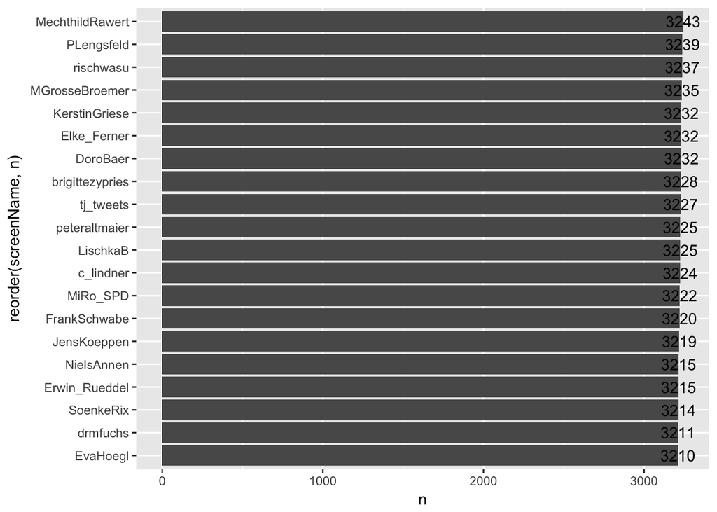

```r
tweets_per_screenName %>%
  top_n(20) %>%
  ggplot +
  aes(x = reorder(screenName, n), y = n) +
  geom_col() +
  coord_flip() +
  geom_text(aes(x = screenName, y = n, label = n))
```

These numbers cannot be (readily) interpreted, because the data are censored.

## How many accounts (per party)

In total, how many accounts are in the dataset?

```r
tweets_df %>%
  count(screenName) %>% nrow
```

```
## [1] 167
```

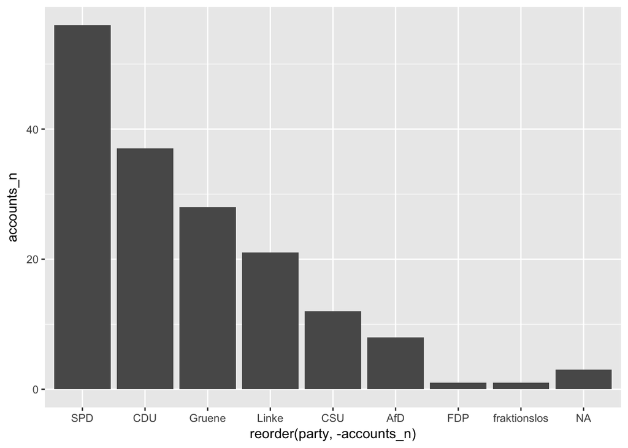

```r
tweets_df %>%
  group_by(party) %>%
  summarise(accounts_n = n_distinct(screenName)) %>%
  ungroup %>%
  ggplot() +
  aes(x = reorder(party, -accounts_n), y = accounts_n) +
  geom_col()
```

## How many tweets per party

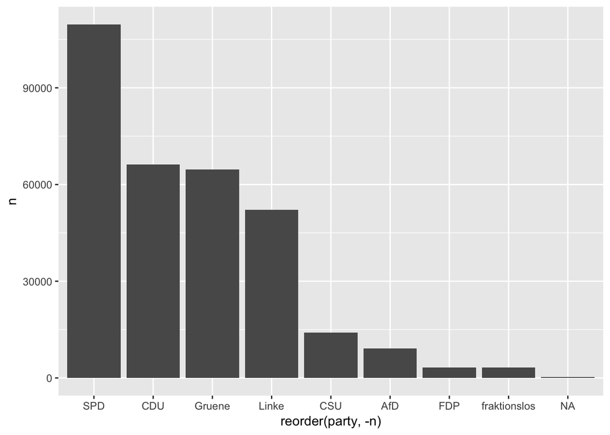

```r
tweets_df %>%
  count(party) %>%
  ggplot +
  aes(x = reorder(party, -n), y = n) +
  geom_col()
```

## Tweets per time

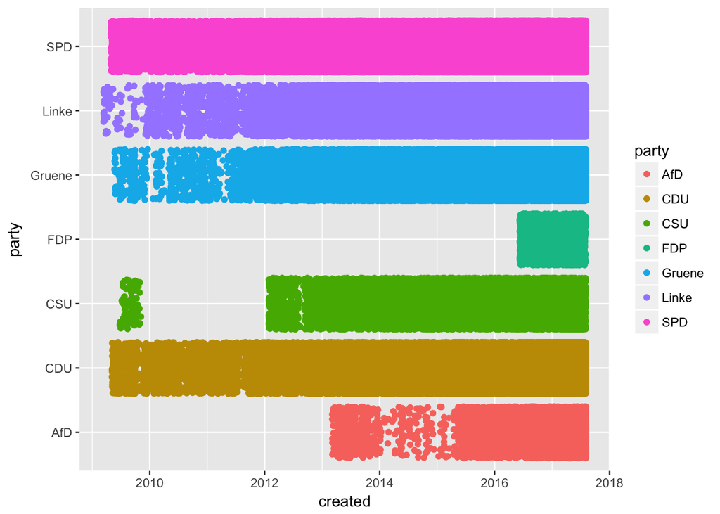

```r
tweets_df %>%
  filter(!party %in% c(NA, "fraktionslos")) %>%
  #sample_n(1000) %>%
  ggplot +
  aes(x = created, y = party) +
  geom_jitter(aes(color = party)) -> p_tweets_per_time

p_tweets_per_time
```

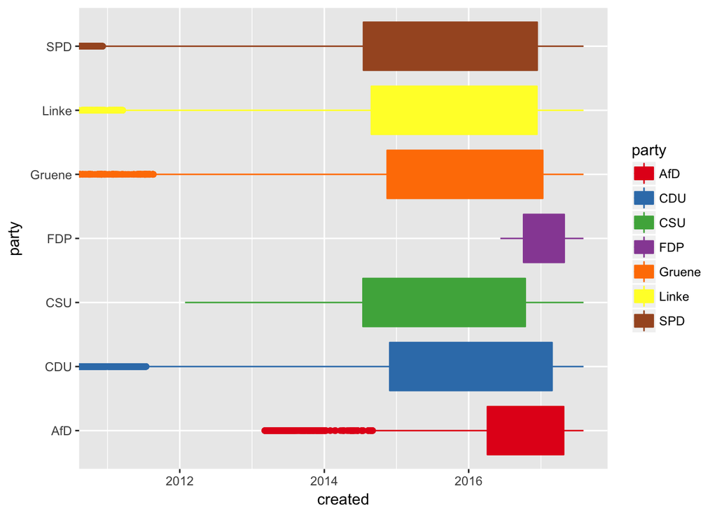

```r
tweets_df %>%
  filter(!party %in% c(NA, "fraktionslos")) %>%
  #sample_n(1000) %>%
  ggplot +
  aes(y = created, x = party) +
  geom_boxplot(aes(fill = party, color = party)) +
  scale_fill_brewer(palette = "Set1") +
  scale_color_brewer(palette = "Set1") +
  coord_flip()
```

## Check tweets of one account: “ArminLaschet”

```r
tweets_df %>%
  filter(screenName == "ArminLaschet") -> tweets_ArminLaschet_long

tweets_ArminLaschet_long %>%
  nrow  # ~13k
```

```
## [1] 3203
```

Most recent/oldest tweet:

```r
tweets_ArminLaschet_long %>%
  filter(screenName == "ArminLaschet") %>%
  summarise(min(created),  # 2016-04-10 12:01:21 - 2017-08-02 21:17:45
            max(created))
```

```
## # A tibble: 1 x 2
##        `min(created)`      `max(created)`
##                <dttm>              <dttm>
## 1 2016-04-10 11:44:45 2017-08-02 21:17:45
```

```r
tweets_ArminLaschet_long %>%
  filter(created %in% c(min(created), max(created))) %>%
  select(text)
```

```
## # A tibble: 2 x 1
##                                                                          text
##                                                                         <chr>
## 1 "RT @WirtschaftNRW: 27 erfolgreiche Förderanträge aus #NRW. Minister @a_pin
## 2 RT @hajoschumacher: Böhmermann und die verlogene Liberalität: Stellen wir u
```

For comparison, we can check whether the the duplicates filter has worked:

```r
tweets_df %>%
  filter(screenName == "ArminLaschet") %>%
  mutate(is_duplicate = duplicated(id)) %>%
  filter(!is_duplicate) %>% nrow  # ~3k
```

```
## [1] 3203
```

```r
tweets_df %>%
  filter(screenName == "ArminLaschet") %>%
  mutate(is_duplicate = duplicated(id)) %>%
  filter(!is_duplicate) %>% nrow  # ~3k
```

```
## [1] 3203
```

Most recent/oldest tweet:

```r
tweets_df %>%
  filter(screenName == "ArminLaschet") %>%
  summarise(min(created),
            max(created))
```

```
## # A tibble: 1 x 2
##        `min(created)`      `max(created)`
##                <dttm>              <dttm>
## 1 2016-04-10 11:44:45 2017-08-02 21:17:45
```

# Oldest tweet in dataset

```r
tweets_df %>% pull(created) %>% min
```

```
## [1] "2009-03-13 15:36:19 UTC"
```

# Get oldest/newest tweet

```r
tweets_df %>%
  group_by(screenName) %>%
  filter(id == min(id)) %>%
  ungroup -> tweets_oldest  # weird error occurred

tweets_oldest %>% as.data.frame -> tweets_oldest


tweets_df %>%
  dplyr::select(screenName, created) %>%
  arrange(created) %>%
  head(10) %>%
  kable
```

| screenName | created |
| --- | --- |
| LoetzschMdB | 2009-03-13 15:36:19 |
| LoetzschMdB | 2009-03-13 15:43:45 |
| LoetzschMdB | 2009-03-13 16:12:43 |
| LoetzschMdB | 2009-03-16 07:55:43 |
| LoetzschMdB | 2009-03-16 11:05:25 |
| LoetzschMdB | 2009-03-16 21:42:55 |
| LoetzschMdB | 2009-03-17 10:51:39 |
| LoetzschMdB | 2009-03-17 13:27:50 |
| LoetzschMdB | 2009-03-17 17:30:58 |
| LoetzschMdB | 2009-03-17 22:06:52 |

```r
tweets_df %>%
  dplyr::select(screenName, created) %>%
  arrange(desc(created)) %>%
  head(10) %>%
  kable
```

| screenName | created |
| --- | --- |
| Markus_Soeder | 2017-08-05 10:58:44 |
| MiRo_SPD | 2017-08-03 19:25:25 |
| Oliver_Krischer | 2017-08-03 19:18:39 |
| EvaHoegl | 2017-08-03 19:16:45 |
| EvaHoegl | 2017-08-03 19:16:34 |
| EvaHoegl | 2017-08-03 19:15:59 |
| Markus_Soeder | 2017-08-03 19:09:00 |
| AndrejHunko | 2017-08-03 19:08:00 |
| OezcanMutlu | 2017-08-03 19:00:47 |
| brigittezypries | 2017-08-03 18:50:40 |

```r
#save(tweets_oldest, file = paste0("data_polit_twitter/tweets_oldest_",lubridate::now()))
```

# Tweets per party

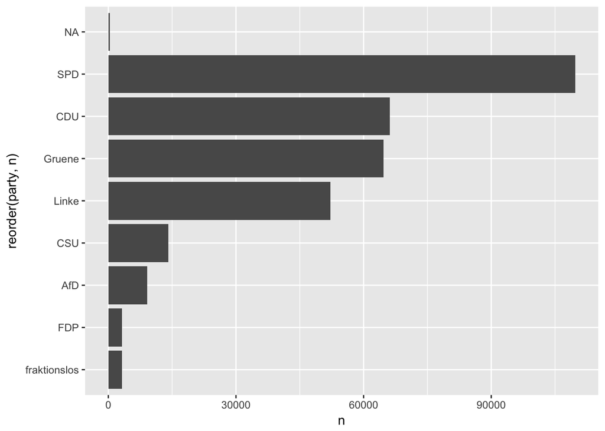

```r
tweets_df %>%
  dplyr::count(party) %>%
  ggplot +
  aes(x = reorder(party, n), y = n) +
  geom_col() +
  coord_flip()
```

# Tweets per person

```r
tweets_df %>%
  group_by(party, screenName) %>%
  summarise(n = n()) %>%
  arrange(-n)
```

```
## # A tibble: 167 x 3
## # Groups:   party [9]
##    party      screenName     n
##    <chr>           <chr> <int>
##  1   SPD MechthildRawert  3243
##  2   CDU      PLengsfeld  3239
##  3   SPD       rischwasu  3237
##  4   CDU  MGrosseBroemer  3235
##  5   CSU        DoroBaer  3232
##  6   SPD     Elke_Ferner  3232
##  7   SPD   KerstinGriese  3232
##  8   SPD brigittezypries  3228
##  9   CDU       tj_tweets  3227
## 10   CDU   peteraltmaier  3225
## # ... with 157 more rows
```

# daily tweets per person

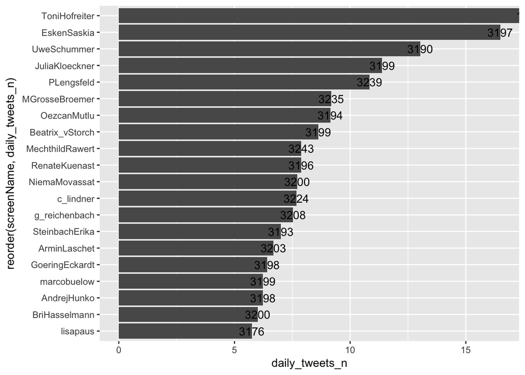

```r
polits_df %>%
  top_n(20) %>%
  ggplot +
  aes(x = reorder(screenName, daily_tweets_n), y = daily_tweets_n) +
  geom_col() +
  coord_flip() +
  geom_text(aes(label = n))
```

For instance, `c_lindner`:

First tweet in dataset:

```r
polits_df %>%
  filter(screenName == "c_lindner") %>%
  dplyr::select(n, first_tweet)
```

```
## # A tibble: 1 x 2
##       n         first_tweet
##   <int>              <dttm>
## 1  3224 2016-06-09 09:10:08
```

## Closer look

More than 3000 tweets in roughly a year? That’s quite a lot; maybe something’s not quite right under the woodshed in these data :(

Let’s have a closer look.

```r
tweets_df %>%
  filter(screenName == "c_lindner") -> lindner
```

How many days exactly do we have for this screenName?

```r
lindner %>%
  summarise(first = min(created),
            last = max(created)) %>%
  mutate(duration_weeks = (last - first) / dweeks(1),
         duration_days = (last - first) / ddays(1))
```

```
## # A tibble: 1 x 4
##                 first                last duration_weeks duration_days
##                <dttm>              <dttm>          <dbl>         <dbl>
## 1 2016-06-09 09:10:08 2017-08-03 11:35:30       60.01442      420.1009
```

About 60 weeks, and 420 days.

Let’s have a look at the distribution of his weekly tweets:

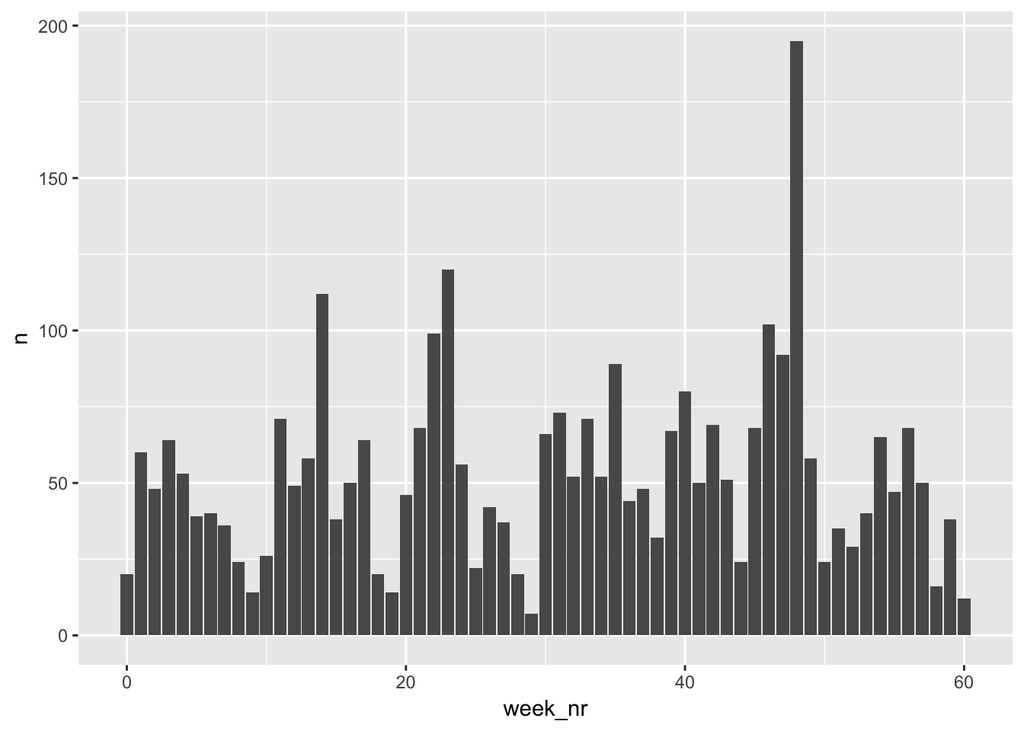

```r
lindner %>%
  mutate(week_nr = (created - min(created)) / dweeks(1),
         day_nr = (created - min(created)) / ddays(1)) %>%
  mutate(week_nr = round(week_nr),
         day_nr = round(day_nr)) -> lindner

lindner %>%
  count(week_nr) %>%
  ggplot() +
  aes(x = week_nr, y = n) +
  geom_col()
```

Let’s compute som stats.

Mean:

```r
(lindner_daily_tweets_M <- nrow(lindner) / 420)
```

```
## [1] 7.67619
```

```r
lindner %>%
  count(day_nr) %>%
  summarise(lindner_daily_tweets_m = mean(n),
            lindner_daily_tweets_sd = sd(n),
            lindner_daily_tweets_md = median(n),
            lindner_daily_tweets_iqr = IQR(n)) -> lindner_stats
```

And the distribution of the daily tweets:

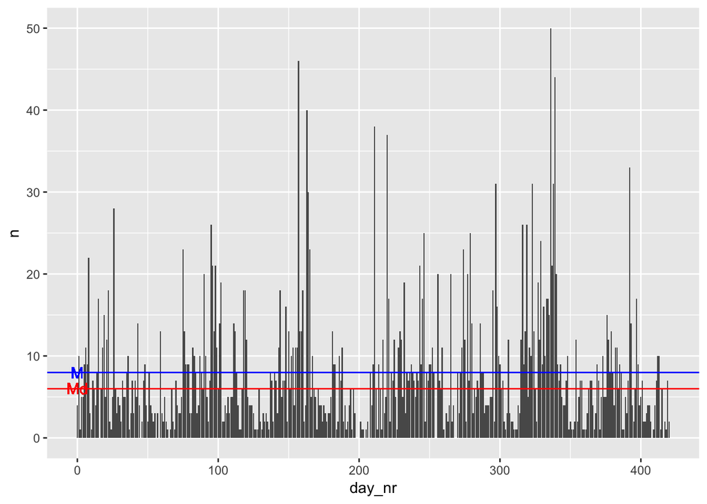

```r
lindner %>%
  count(day_nr) %>%
  ggplot() +
  aes(x = day_nr, y = n) +
  geom_col() +
  geom_hline(yintercept = lindner_stats %>%
               slice(1) %>%
               pull(lindner_daily_tweets_m),
             color = "blue") +
  geom_text(label = "M", aes(y= lindner_stats %>%
               slice(1) %>%
               pull(lindner_daily_tweets_m), x = 0), color = "blue") +
  geom_hline(yintercept = lindner_stats %>%
               slice(1) %>%
               pull(lindner_daily_tweets_md),
             color = "red") +
  geom_text(label = "Md", aes(y= lindner_stats %>%
               slice(1) %>%
               pull(lindner_daily_tweets_md), x = 0), color = "red")
```

## Duplicates for Lindner?

Looks all quite reasonable.

Duplicates?

```r
lindner %>%
  mutate(is_duplicate = duplicated(id)) %>%
  filter(is_duplicate) %>% nrow
```

```
## [1] 0
```

Nup.

## Look at some peak days

```r
lindner %>%
 count(day_nr) %>%
  mutate(my_date = ymd("2016-06-09") + day_nr) %>%
  arrange(-n)
```

```
## # A tibble: 404 x 3
##    day_nr     n    my_date
##     <dbl> <int>     <date>
##  1    336    50 2017-05-11
##  2    157    46 2016-11-13
##  3    339    44 2017-05-14
##  4    163    40 2016-11-19
##  5    211    38 2017-01-06
##  6    220    37 2017-01-15
##  7    392    33 2017-07-06
##  8    297    31 2017-04-02
##  9    323    31 2017-04-28
## 10    338    31 2017-05-13
## # ... with 394 more rows
```

Ok, let’s check Twitter how much he tweeted on 2017-05-11.

… It was Rally day in NRW… …

Hm, I counted roughly 38. Dataframes says 50. Maybe some deletion?

Let’s look at those 50.

```r
lindner %>%
  filter(created > dmy("10-05-2017"), created < dmy("12-05-2017")) %>%
  select(text, created, id) -> lindner_most_tweeted
```

## Tweets deleted?

```r
lindner_most_tweeted %>%
  slice(4:6) %>%
  select(id)
```

```
## # A tibble: 3 x 1
##                   id
##                <chr>
## 1 862756714633973761
## 2 862754301554425856
## 3 862751440846159872
```

## Conclusion

OK, so it appears there’s an explanation in the differing number of tweets: There are some tweets missing in the timeline on the Website, appearingly deleted by the owner of the account.

# Daily tweets per party

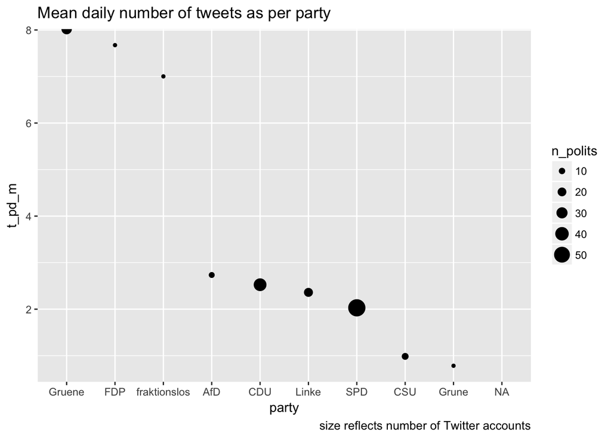

```r
polits_df %>%
  group_by(party) %>%
  summarise(t_pd_m = mean(daily_tweets_n),
            n_polits = n()) %>%
  arrange(-t_pd_m) %>%
  ungroup %>%
  mutate(party = factor(party, party)) %>%
  ggplot +
  aes(x = party, y = t_pd_m) +
  geom_point(aes(size = n_polits)) +
  labs(title = "Mean daily number of tweets as per party",
       caption = "size reflects number of Twitter accounts") +
  scale_radius()
```

# Most frequent words per party

## Read stopwords, unnest tokens, compute frequencies

```r
data(stopwords_de, package = "lsa")
stopwords_de <- data_frame(token = stopwords_de)

stopwords_de_ses <- read_csv("data/stopwords_de_ses.csv")

stopwords_de_ses %>%
  rename(token = stopword) -> stopwords_de_ses
```

Now unnest the tokens (1-grams):

```r
tweets_df %>%
  select(party, text, screenName) %>%
  unnest_tokens(output = token, input = text) %>%
  dplyr::filter(str_detect(token, "[a-z]")) -> tweets_token_including_stopwords
```

`unnest_tokens` performs `str_to_lower` too.

```r
tweets_token_including_stopwords %>%
  anti_join(stopwords_de_ses, by = "token") %>%
  anti_join(stopwords_de, by = "token") -> tweet_tokens
```

This one needs some seconds:

```r
#load("../data_polit_twitter/tweet_tokens.Rdata")
tweet_tokens %>%
  count(token, sort = TRUE) -> tweets_word_count
```

```r
tweets_word_count %>%
  top_n(100) %>%
  as.data.frame %>%
  arrange(-n)
```

```
##               token     n
## 1             heute 19653
## 2               spd 15823
## 3             jetzt 13367
## 4               cdu 11074
## 5            berlin  9540
## 6         bundestag  8566
## 7               afd  7142
## 8             danke  6351
## 9                ja  6069
## 10            schon  5895
## 11             gute  5836
## 12      deutschland  5751
## 13               eu  5677
## 14             will  5664
```

[output cut: 86 more lines]

## Visualize summary frequencies (bars)

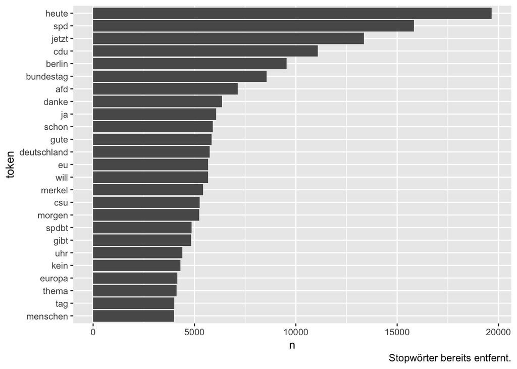

```r
tweets_word_count %>%
  top_n(25) %>%
  arrange(-n) %>%
  mutate(token = factor(token, levels = rev(token))) %>%
  ggplot +
  aes(x = token, y = n) +
  geom_col() +
  scale_fill_viridis() +
  coord_flip()  +
  labs("Welche Wörter wurden am häufigsten getweetet?",
       caption = "Stopwörter bereits entfernt.")
```

## wordcloud, summary frequencies

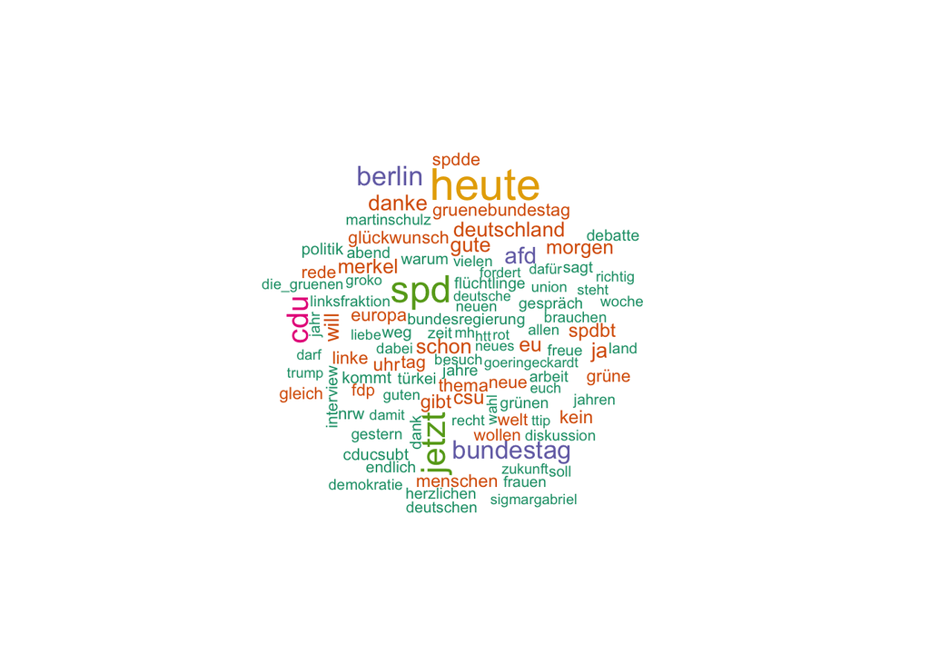

```r
wordcloud(words = tweets_word_count$token,
          freq = tweets_word_count$n,
          max.words = 100,
          scale = c(2,.5),
          colors=brewer.pal(6, "Dark2"))
```

## Most frequent terms per party

```r
load("../data_polit_twitter/tweet_tokens.Rdata")


tweet_tokens %>%
  count(party, token, sort = TRUE) -> tweets_per_party_word_count
```

## Plot frequencies par party (bars)

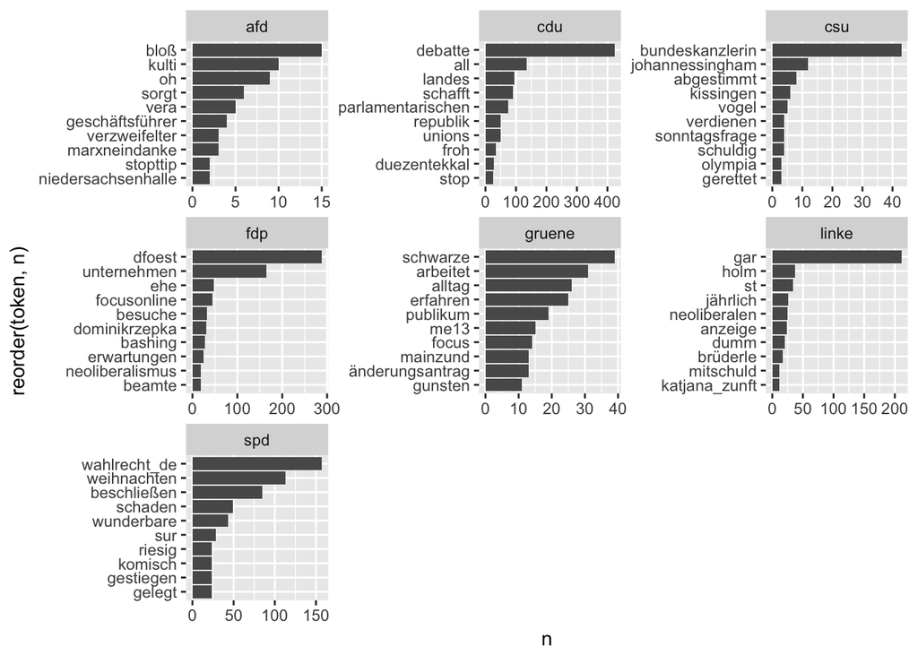

```r
tweets_per_party_word_count %>%
  filter(!(party %in% c("NA", "fraktionslos", NA))) %>%
  sample_n(1000) %>%
  group_by(party) %>%
  arrange(-n) %>%
  slice(1:10) %>%
  ungroup %>%
  mutate(token = factor(token)) %>%
  ggplot() +
  aes(x = reorder(token, n), y = n) +
  geom_col() +
  facet_wrap(~party, scales = "free", drop = TRUE) +
  coord_flip() -> plot_tweets_per_party_word_count

plot_tweets_per_party_word_count
```

## Same, but with Wordstemming

```r
tweet_tokens %>%
  mutate(token = wordStem(.$token, language = "german")) %>%
  count(party, token, sort = TRUE) -> tweets_per_party_word_count_stemmed


names(tweets_per_party_word_count_stemmed)
```

```
## [1] "party" "token" "n"
```

```r
save(tweets_per_party_word_count_stemmed,
     file = "../data_polit_twitter/tweets_per_party_word_count_stemmed.Rdata")
```

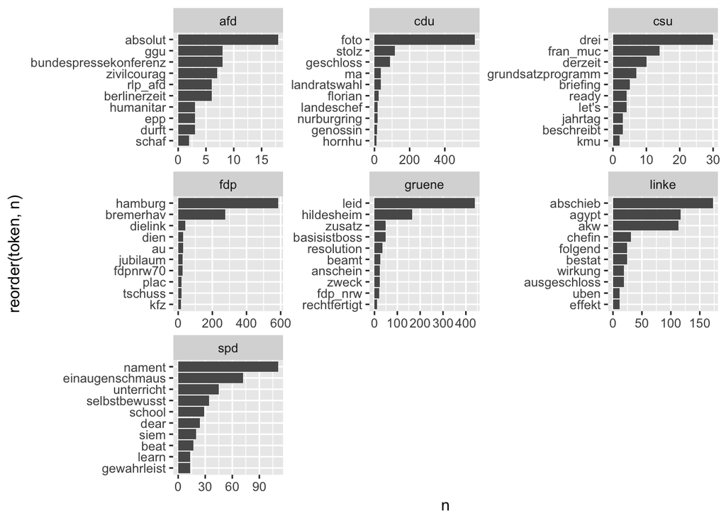

```r
tweets_per_party_word_count_stemmed %>%
  filter(!(party %in% c("NA", "fraktionslos", NA))) %>%
  sample_n(1000) %>%
  group_by(party) %>%
  arrange(-n) %>%
  slice(1:10) %>%
  ungroup %>%
  mutate(token = factor(token)) %>%
  ggplot() +
  aes(x = reorder(token, n), y = n) +
  geom_col() +
  facet_wrap(~party, scales = "free", drop = TRUE) +
  coord_flip()
```

## Stemm party variants (spdde –> spd)

Also, there are duplicates such as “spdbt” “spdde” and “spd”; those instances should be stemmed to “spd”, and the like.

```r
stem_term <- function(df, col, stem_output){
 # this function looks for '\\w+stem_output\\w+' and replaces each element by `stem_output`

    # parameters:
  # df: data,
  # col: column to be stemmed,
  # stem_output: desired output after stemming

  # output
  # vector of tokens, where hits are replaced


  col_quo <- enquo(col)
  col_name <- quo_name(col_quo)
  stem_quo <- enquo(stem_output)
  stem_name <- quo_name(stem_quo)


  # gsub/str_replace do not understands functions with more than 1 parameter
  pattern1 <- paste0(stem_output,"\\w+")
  pattern2 <- paste0("\\w+",stem_output)


    df %>%
      mutate(col_stemmed = str_replace(string = !!col_quo,
                                       pattern = pattern1,
                                       replacement =
                                       stem_output)) %>%
      # mutate(col_stemmed = str_replace(string = !!col_quo,
      #                                  pattern = pattern2,
      #                                  replacement =
      #                                  stem_output)) %>%
    pull(col_stemmed) -> output


  return(output)

}
```

For comparison, execute this function non-programmatically, but interactively (for debugging reasons):

```r
party <- "afd"

my_pattern <- paste0(party, "\\w+")

tweets_per_party_word_count_stemmed %>%
  mutate(output = str_replace(string = .$token,
                         pattern = my_pattern,
                         replacement = "afd")) %>%
  filter(str_detect(token, "afd"))
```

```
## # A tibble: 376 x 4
##     party           token     n     output
##     <chr>           <chr> <int>      <chr>
##  1    afd             afd  3371        afd
##  2    spd             afd  1258        afd
##  3    fdp             afd  1148        afd
##  4    cdu             afd  1058        afd
##  5  linke             afd   678        afd
##  6 gruene             afd   563        afd
##  7    afd        afd_bund   460        afd
##  8    afd wahlen_afd_2016   198 wahlen_afd
##  9    afd       afdberlin   172        afd
## 10    afd      afdkompakt   123        afd
## # ... with 366 more rows
```

Now see whether the function runs as expected:

```r
#debug(stem_party)
dummy <- stem_term(df = tweets_per_party_word_count_stemmed,
                     col = token,
                     stem_output = "afd")

dummy %>%
  as_tibble %>%
  filter(str_detect(dummy, "afd"))
```

```
## # A tibble: 376 x 1
##         value
##         <chr>
##  1        afd
##  2        afd
##  3        afd
##  4        afd
##  5        afd
##  6        afd
##  7        afd
##  8 wahlen_afd
##  9        afd
## 10        afd
## # ... with 366 more rows
```

Get different parties:

```r
parties <- polits_df %>% filter(!is.na(party)) %>% pull(party) %>% unique
parties
```

```
## [1] "Grune"        "SPD"          "Gruene"       "CSU"
## [5] "AfD"          "Linke"        "CDU"          "FDP"
## [9] "fraktionslos"
```

```r
tweets_per_party_word_count_stemmed2 <- tweets_per_party_word_count_stemmed


for(i in seq_along(parties)){
  tweets_per_party_word_count_stemmed2$token <-
    stem_term(df = tweets_per_party_word_count_stemmed,
              col = token,
              stem_output = parties[i])

}
```

Plot again with party-related terms stemmed:

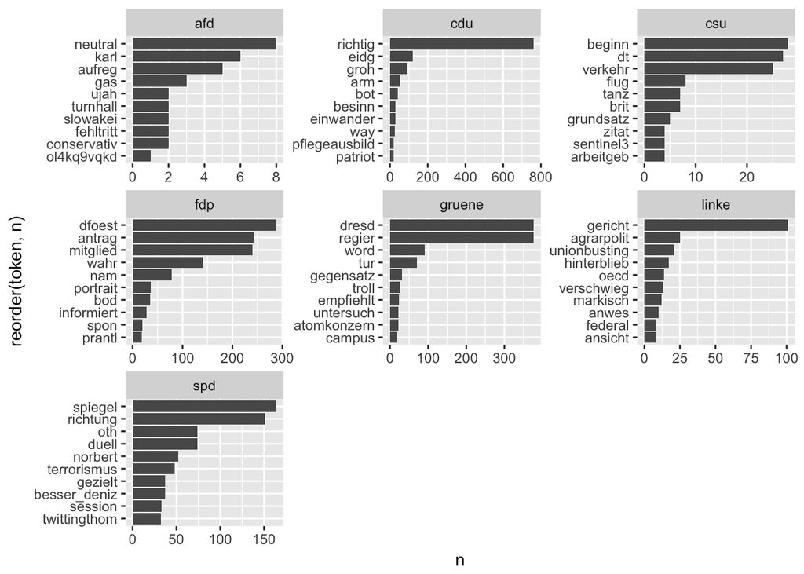

```r
tweets_per_party_word_count_stemmed2 %>%
  filter(!(party %in% c("NA", "fraktionslos", NA))) %>%
  sample_n(1000) %>%
  group_by(party) %>%
  arrange(-n) %>%
  slice(1:10) %>%
  ungroup %>%
  mutate(token = factor(token)) %>%
  ggplot() +
  aes(x = reorder(token, n), y = n) +
  geom_col() +
  facet_wrap(~party, scales = "free", drop = TRUE) +
  coord_flip()
```

# Word lengths

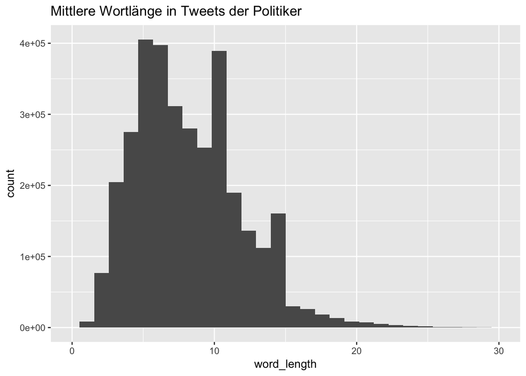

```r
tweet_tokens %>%
  mutate(word_length = str_length(token)) %>%
  group_by(screenName) %>%
  ggplot +
  aes(x = word_length) +
  geom_histogram() +
  xlim(0,30) +
  labs(title = "Mittlere Wortlänge in Tweets der Politiker")
```

```r
tweet_tokens %>%
  mutate(word_length = str_length(token)) %>%
  group_by(screenName) %>%
  summarise(word_length_avg = mean(word_length, na.rm = T),
            word_length_md = median(word_length, na.rm = T)) -> screenName_word_lengths
```

# What’s speaks the AfD about what the others are not interested in?

## Top 100 token per party

```r
parties_df <- data_frame(
  party = parties,
  party_ID = 1:length(parties)
)
tweets_per_party_word_count_stemmed %>%
  mutate(party = str_to_lower(party)) %>%
  group_by(party) %>%
  arrange(-n) %>%
  slice(1:100) %>%
  left_join(parties_df, by = "party") %>%
  filter(!is.na(party_ID)) -> top_100s

top_100s %>%
  count(party_ID)
```

```
## # A tibble: 1 x 3
## # Groups:   party [1]
##          party party_ID    nn
##          <chr>    <int> <int>
## 1 fraktionslos        9   100
```

This one is still buggy:

```r
mat <- matrix(0, nrow = 9, ncol = 9)

setdiff(top_100s$token[top_100s$party_ID == 8],
        top_100s$token[top_100s$party_ID == 9])


outer(1:nrow(mat), 1:ncol(mat), FUN = function(i,j) setdiff(top_100s$token[top_100s$party_ID == i],top_100s$token[top_100s$party_ID == j]))
```

# Save token data

```r
save(tweet_tokens, file = "../data_polit_twitter/tweet_tokens.Rdata")

save(tweets_token_including_stopwords, file = "../data_polit_twitter/tweets_token_including_stopwords.Rdata")

save(screenName_word_lengths,
     file = "../data_polit_twitter/screenName_word_lengths.Rdata")
```